# 06_robustness_analyses

Lena Kuschel

10 November 2020

## Robustness Analyses

Here, we perform additional robustness checks including age in each model as a covariate.

### Library

```r
library(formr)
library(effects)
library(effectsize)
library(lme4)
library(sjstats)
library(lmerTest)
library(dplyr)
```

```r
library(ggplot2)
library(RColorBrewer)
```

### Data

Load selected data based on 03_codebook

```r
data_included_documented = read.csv(file = "data_included_documented.csv")[,-1]
```

#### Preferred Relationship Options

##### H1a Interest in Single Life

H1a There is a negative linear link between right-wing political orientation and women’s interest in being single.  
Outcome: Ratings for interest in single life. Predictors: Political Orientation & Age. Random intercept and random slope for country.

###### Models

```r
model_interest_single_robustcheck <- lmer(interest_single ~ political_orientation + age + (1+political_orientation|country), data = data_included_documented)
```

###### Summary

```r
summary(model_interest_single_robustcheck)
```

```
## Linear mixed model fit by REML. t-tests use Satterthwaite's method [
## lmerModLmerTest]
## Formula:
## interest_single ~ political_orientation + age + (1 + political_orientation |
##     country)
##    Data: data_included_documented
##
## REML criterion at convergence: 51944
##
## Scaled residuals:
##      Min       1Q   Median       3Q      Max
## -1.73779 -0.94970  0.01725  0.67427  2.76366
##
## Random effects:
##  Groups   Name                  Variance Std.Dev. Corr
##  country  (Intercept)           0.07462  0.27316
##           political_orientation 0.00290  0.05385  0.37
##  Residual                       2.96477  1.72185
## Number of obs: 13204, groups:  country, 144
##
## Fixed effects:
##                         Estimate Std. Error         df t value Pr(>|t|)
## (Intercept)            2.753e+00  7.728e-02  1.069e+02  35.621  < 2e-16 ***
## political_orientation -7.107e-02  1.555e-02  1.525e+01  -4.569 0.000354 ***
## age                   -1.126e-02  2.203e-03  1.317e+04  -5.111 3.25e-07 ***
## ---
## Signif. codes:  0 '***' 0.001 '**' 0.01 '*' 0.05 '.' 0.1 ' ' 1
##
## Correlation of Fixed Effects:
##             (Intr) pltcl_
## pltcl_rnttn -0.340
## age         -0.705  0.033
```

```r
confint(model_interest_single_robustcheck, level = 0.997)
```

```
## Computing profile confidence intervals ...
```

[output not shown]

[output cut: 205 more lines]

[output not shown]

```
## Warning in FUN(X[[i]], ...): non-monotonic profile for .sig02
```

```
## Warning in confint.thpr(pp, level = level, zeta = zeta): bad spline fit
## for .sig02: falling back to linear interpolation
```

```
## Warning in regularize.values(x, y, ties, missing(ties), na.rm = na.rm):
## collapsing to unique 'x' values
```

```
##                             0.15 %      99.85 %
## .sig01                 0.143980683  0.487850067
## .sig02                -0.640655333  1.000000000
## .sig03                 0.004949959  0.126067594
## .sigma                 1.690732627  1.753848468
## (Intercept)            2.520866889  2.983875803
## political_orientation -0.120435200 -0.018954539
## age                   -0.017788139 -0.004705403
```

###### Standardized Coefficients

```r
standardize_parameters(model_interest_single_robustcheck, method = "basic", ci = 0.997)
```

```
## Parameter             | Coefficient (std.) |      1e+02% CI
## -----------------------------------------------------------
## (Intercept)           |               0.00 | [ 0.00,  0.00]
## political_orientation |              -0.05 | [-0.09, -0.02]
## age                   |              -0.04 | [-0.07, -0.02]
##
## # Standardization method: Basic
```

###### Plot

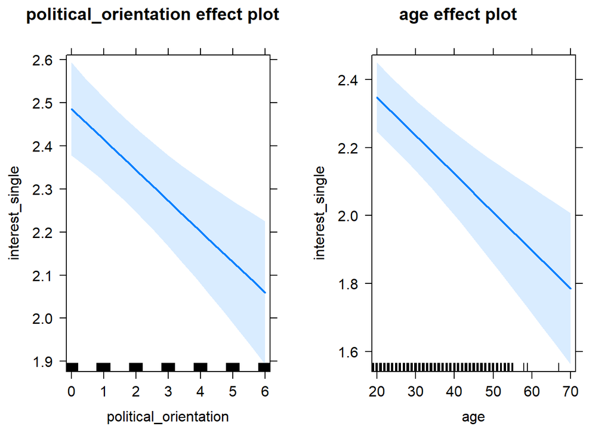

```r
lmer(interest_single ~ political_orientation + age + (1+political_orientation|country),
       data = data_included_documented) %>%
    allEffects() %>%
    plot()
```

##### H1b Interest in sexual, non-romantic relationships

H1b There is a negative linear link between right-wing political orientation and women’s interest in having sexual, non-romantic relationships (e.g., hookups, one-night stands). Outcome: Ratings for interest in having sexual, non-romantic relationships. Predictors: Political Orientation & Age. Random intercept and random slope for country.

###### Models

```r
#model_interest_sexrel_robustcheck <- lmer(interest_sexrel ~ political_orientation + age + (1+political_orientation|country), data = data_included_documented)

#Model failed to converge, drop random slope:
model_interest_sexrel_robustcheck <- lmer(interest_sexrel ~ political_orientation + age + (1|country), data = data_included_documented)
```

###### Summary

```r
summary(model_interest_sexrel_robustcheck)
```

```
## Linear mixed model fit by REML. t-tests use Satterthwaite's method [
## lmerModLmerTest]
## Formula: interest_sexrel ~ political_orientation + age + (1 | country)
##    Data: data_included_documented
##
## REML criterion at convergence: 53371.4
##
## Scaled residuals:
##     Min      1Q  Median      3Q     Max
## -3.3703 -0.8560 -0.0450  0.7151  2.9380
##
## Random effects:
##  Groups   Name        Variance Std.Dev.
##  country  (Intercept) 0.5092   0.7136
##  Residual             3.3017   1.8171
## Number of obs: 13189, groups:  country, 144
##
## Fixed effects:
##                         Estimate Std. Error         df t value Pr(>|t|)
## (Intercept)            3.451e+00  1.066e-01  3.155e+02  32.369  < 2e-16 ***
## political_orientation  3.260e-02  1.184e-02  1.317e+04   2.752  0.00593 **
## age                   -3.740e-02  2.329e-03  1.316e+04 -16.060  < 2e-16 ***
## ---
## Signif. codes:  0 '***' 0.001 '**' 0.01 '*' 0.05 '.' 0.1 ' ' 1
##
## Correlation of Fixed Effects:
##             (Intr) pltcl_
## pltcl_rnttn -0.317
## age         -0.545  0.055
```

```r
confint(model_interest_sexrel_robustcheck, level = 0.997)
```

```
## Computing profile confidence intervals ...
```

```
##                             0.15 %     99.85 %
## .sig01                 0.546413040  0.94223807
## .sigma                 1.784111757  1.85074676
## (Intercept)            3.133373202  3.76904435
## political_orientation -0.002545255  0.06777359
## age                   -0.044315663 -0.03049071
```

###### Standardized Coefficients

```r
standardize_parameters(model_interest_sexrel_robustcheck, method = "basic", ci = 0.997)
```

```
## Parameter             | Coefficient (std.) |      1e+02% CI
## -----------------------------------------------------------
## (Intercept)           |               0.00 | [ 0.00,  0.00]
## political_orientation |               0.02 | [ 0.00,  0.05]
## age                   |              -0.13 | [-0.15, -0.10]
##
## # Standardization method: Basic
```

```r
ci(standardize_parameters(model_interest_sexrel_robustcheck, method = "basic"), ci = 0.997)
```

```
##               Parameter   CI       CI_low    CI_high
## 1           (Intercept) 99.7  0.000000000  0.0000000
## 2 political_orientation 99.7 -0.001720247  0.0455725
## 3                   age 99.7 -0.150608036 -0.1036203
```

```r
#calculate by hand to get exact numbers
```

###### Plot

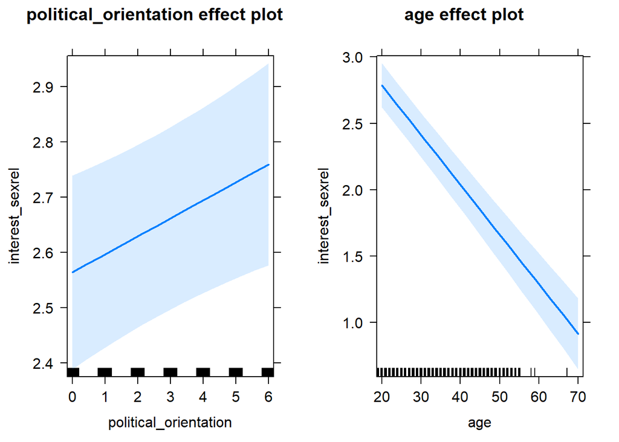

```r
lmer(interest_sexrel ~ political_orientation + age + (1|country),
       data = data_included_documented) %>%
    allEffects() %>%
    plot()
```

##### H1c Interest in non-monogamous relationships

H1c There is a negative linear link between right-wing political orientation and women’s interest in having non-monogamous relationships. Outcome: Ratings for interest in having non-monogamous relationships. Predictors: Political Orientation & Age. Random intercept and random slope for country.

###### Models

```r
model_interest_nonmonrel_robustcheck <- lmer(interest_nonmonrel ~ political_orientation + age + (1+political_orientation|country), data = data_included_documented)
```

###### Summary

```r
summary(model_interest_nonmonrel_robustcheck)
```

```
## Linear mixed model fit by REML. t-tests use Satterthwaite's method [
## lmerModLmerTest]
## Formula:
## interest_nonmonrel ~ political_orientation + age + (1 + political_orientation |
##     country)
##    Data: data_included_documented
##
## REML criterion at convergence: 47772.5
##
## Scaled residuals:
##     Min      1Q  Median      3Q     Max
## -1.1012 -0.5989 -0.4719  0.1993  3.8267
##
## Random effects:
##  Groups   Name                  Variance Std.Dev. Corr
##  country  (Intercept)           0.044672 0.21136
##           political_orientation 0.002861 0.05348  -0.28
##  Residual                       2.202530 1.48409
## Number of obs: 13141, groups:  country, 144
##
## Fixed effects:
##                         Estimate Std. Error         df t value Pr(>|t|)
## (Intercept)            1.065e+00  6.784e-02  1.037e+02  15.698  < 2e-16 ***
## political_orientation -6.283e-02  1.508e-02  2.111e+01  -4.165 0.000433 ***
## age                    7.849e-04  1.901e-03  1.313e+04   0.413 0.679734
## ---
## Signif. codes:  0 '***' 0.001 '**' 0.01 '*' 0.05 '.' 0.1 ' ' 1
##
## Correlation of Fixed Effects:
##             (Intr) pltcl_
## pltcl_rnttn -0.507
## age         -0.693  0.031
```

```r
confint(model_interest_nonmonrel_robustcheck, level = 0.997)
```

```
## Computing profile confidence intervals ...
```

```
##                             0.15 %      99.85 %
## .sig01                 0.096950046  0.397355069
## .sig02                -0.845523439  1.000000000
## .sig03                 0.007685623  0.120726697
## .sigma                 1.457201607  1.511716499
## (Intercept)            0.857999824  1.266828591
## political_orientation -0.110606945 -0.013536215
## age                   -0.004857166  0.006429072
```

###### Standardized Coefficients

```r
standardize_parameters(model_interest_nonmonrel_robustcheck, method = "basic", ci = 0.997)
```

```
## Parameter             | Coefficient (std.) |      1e+02% CI
## -----------------------------------------------------------
## (Intercept)           |               0.00 | [ 0.00,  0.00]
## political_orientation |              -0.06 | [-0.10, -0.02]
## age                   |           3.60e-03 | [-0.02,  0.03]
##
## # Standardization method: Basic
```

###### Plot

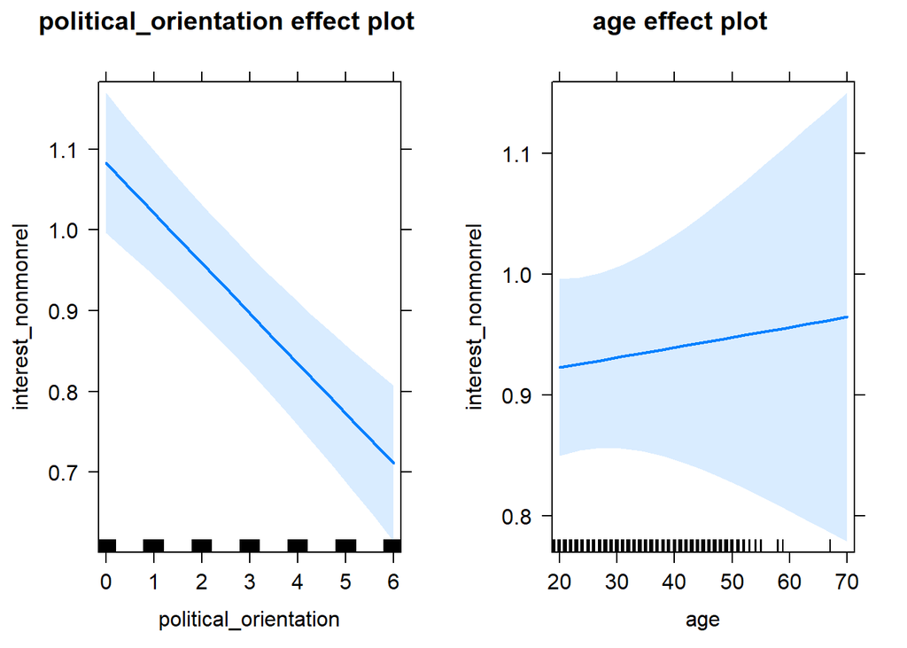

```r
lmer(interest_nonmonrel ~ political_orientation + age + (1 | country),
       data = data_included_documented) %>%
    allEffects() %>%
    plot()
```

##### H1d Interest in monogamous relationships

H1d There is no link between right-wing political orientation and women’s interest in having monogamous relationships. Outcome: Ratings for interest in having monogamous relationships. Predictors: Political Orientation & Age. Random intercept and random slope for country.

###### Models

```r
#model_interest_monrel_robustcheck <- lmer(interest_monrel ~ political_orientation + age + (1+political_orientation|country), data = data_included_documented)

#drop random slope as model did not converge
model_interest_monrel_robustcheck <- lmer(interest_monrel ~ political_orientation + age + (1|country), data = data_included_documented)
```

###### Summary

```r
summary(model_interest_monrel_robustcheck)
```

```
## Linear mixed model fit by REML. t-tests use Satterthwaite's method [
## lmerModLmerTest]
## Formula: interest_monrel ~ political_orientation + age + (1 | country)
##    Data: data_included_documented
##
## REML criterion at convergence: 51422.2
##
## Scaled residuals:
##     Min      1Q  Median      3Q     Max
## -3.3093 -0.3397  0.4513  0.6124  1.3790
##
## Random effects:
##  Groups   Name        Variance Std.Dev.
##  country  (Intercept) 0.1651   0.4064
##  Residual             2.8849   1.6985
## Number of obs: 13161, groups:  country, 144
##
## Fixed effects:
##                        Estimate Std. Error        df t value Pr(>|t|)
## (Intercept)           4.502e+00  8.333e-02 4.409e+02  54.025  < 2e-16 ***
## political_orientation 1.319e-03  1.106e-02 1.316e+04   0.119    0.905
## age                   1.635e-02  2.174e-03 1.315e+04   7.521 5.79e-14 ***
## ---
## Signif. codes:  0 '***' 0.001 '**' 0.01 '*' 0.05 '.' 0.1 ' ' 1
##
## Correlation of Fixed Effects:
##             (Intr) pltcl_
## pltcl_rnttn -0.379
## age         -0.649  0.054
```

```r
confint(model_interest_monrel_robustcheck, level = 0.997)
```

```
## Computing profile confidence intervals ...
```

```
##                             0.15 %    99.85 %
## .sig01                 0.292308281 0.56953569
## .sigma                 1.667687944 1.72999326
## (Intercept)            4.254370701 4.75057055
## political_orientation -0.031532084 0.03412521
## age                    0.009901564 0.02280942
```

###### Standardized Coefficients

```r
standardize_parameters(model_interest_monrel_robustcheck, method = "basic", ci = 0.997)
```

```
## Parameter             | Coefficient (std.) |     1e+02% CI
## ----------------------------------------------------------
## (Intercept)           |               0.00 | [ 0.00, 0.00]
## political_orientation |           1.02e-03 | [-0.02, 0.03]
## age                   |               0.06 | [ 0.04, 0.09]
##
## # Standardization method: Basic
```

###### Plot

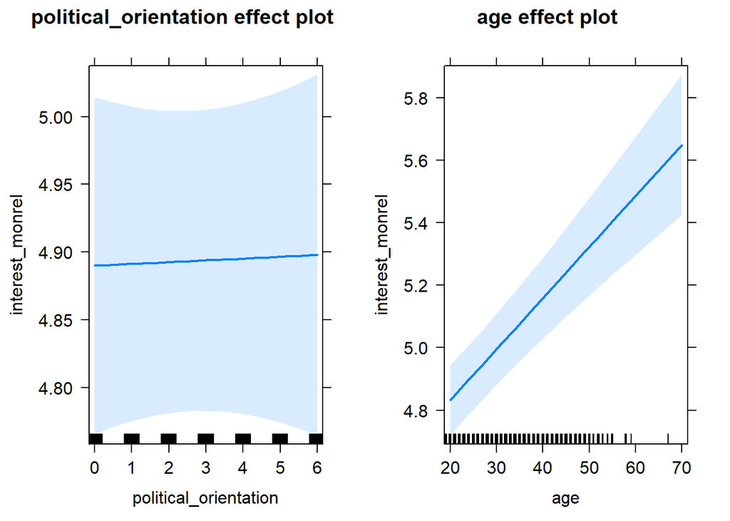

```r
lmer(interest_monrel ~ political_orientation + age + (1| country),
       data = data_included_documented) %>%
    allEffects() %>%
    plot()
```

#### Political, ethnic and religious similarity

##### H2a Preference for similarity in political beliefs

H2a There is no linear link between right-wing political orientation and women’s preferences for partner’s similar political beliefs and values when controlling for a quadratic link. There is a positive quadratic link between right-wing political orientation and women’s preferences for partner’s similar political beliefs and values when controlling for a linear link. Outcome: Preference ratings for partner’s similar political beliefs and values. Predictors: Political Orientation & Age. Random intercept and random slope for country.

###### Models

```r
model_pref_politicalsim_robustcheck = lmer(pref_politicalsim ~ political_orientation + I(political_orientation^2) + age +
                                 (1+political_orientation|country),
                               data = data_included_documented)
```

###### Summary

```r
summary(model_pref_politicalsim_robustcheck)
```

```
## Linear mixed model fit by REML. t-tests use Satterthwaite's method [
## lmerModLmerTest]
## Formula:
## pref_politicalsim ~ political_orientation + I(political_orientation^2) +
##     age + (1 + political_orientation | country)
##    Data: data_included_documented
##
## REML criterion at convergence: 52122.3
##
## Scaled residuals:
##     Min      1Q  Median      3Q     Max
## -2.8927 -0.6656  0.1623  0.7391  2.2907
##
## Random effects:
##  Groups   Name                  Variance Std.Dev. Corr
##  country  (Intercept)           0.50265  0.7090
##           political_orientation 0.01594  0.1263   -0.71
##  Residual                       3.23246  1.7979
## Number of obs: 12946, groups:  country, 144
##
## Fixed effects:
##                              Estimate Std. Error         df t value Pr(>|t|)
## (Intercept)                 3.283e+00  1.237e-01  1.121e+02   26.55   <2e-16
## political_orientation      -6.327e-01  4.102e-02  1.726e+02  -15.42   <2e-16
## I(political_orientation^2)  1.068e-01  6.188e-03  1.112e+04   17.26   <2e-16
## age                         2.690e-02  2.332e-03  1.292e+04   11.54   <2e-16
##
## (Intercept)                ***
## political_orientation      ***
## I(political_orientation^2) ***
## age                        ***
## ---
## Signif. codes:  0 '***' 0.001 '**' 0.01 '*' 0.05 '.' 0.1 ' ' 1
##
## Correlation of Fixed Effects:
##             (Intr) pltcl_ I(_^2)
## pltcl_rnttn -0.615
## I(pltcl_^2)  0.259 -0.774
## age         -0.480  0.047 -0.041
```

```r
confint(model_pref_politicalsim_robustcheck, level = 0.997)
```

```
## Computing profile confidence intervals ...
```

```
##                                 0.15 %     99.85 %
## .sig01                      0.45554687  1.05462919
## .sig02                     -0.92772586 -0.08283151
## .sig03                      0.05447135  0.23284927
## .sigma                      1.76495735  1.83168308
## (Intercept)                 2.89461062  3.65549423
## political_orientation      -0.75674330 -0.50180316
## I(political_orientation^2)  0.08840717  0.12535351
## age                         0.01997582  0.03382036
```

###### Standardized Coefficients

```r
standardize_parameters(model_pref_politicalsim_robustcheck, method = "refit", ci = 0.997)
```

```
## Parameter                  | Coefficient (std.) |      1e+02% CI
## ----------------------------------------------------------------
## (Intercept)                |              -0.12 | [-0.22, -0.01]
## political_orientation      |              -0.07 | [-0.12, -0.01]
## I(political_orientation^2) |               0.10 | [ 0.09,  0.12]
## age                        |               0.10 | [ 0.07,  0.12]
##
## # Standardization method: Refit
```

```r
#ci(standardize_parameters(model_pref_politicalsim_robustcheck, method = "refit"), ci = 0.997)
```

###### Plot

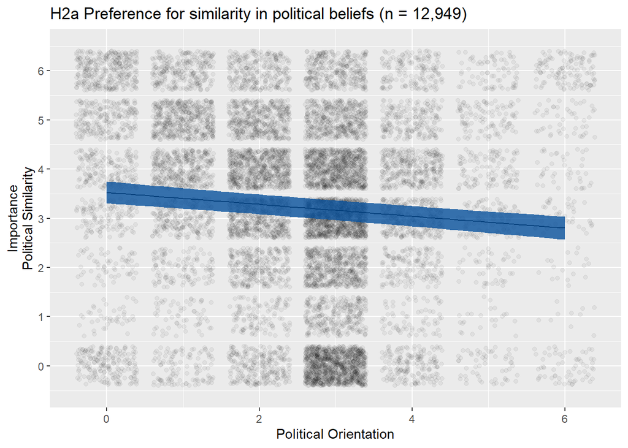

```r
effects1 = lmer(pref_politicalsim ~ political_orientation + age + (1|country),
             data = data_included_documented) %>%
  allEffects(confidence.level = 0.997, xlevels = 49) %>%
  as.data.frame()

effects1 = as.data.frame(effects1$political_orientation)

n = data_included_documented %>%
  filter(!is.na(pref_politicalsim)) %>%
  count()

plot1 = ggplot() +
  geom_jitter(data = data_included_documented, aes(x = political_orientation, y = pref_politicalsim),
              alpha = 0.05) +
  geom_line(data = effects1, aes(x = political_orientation, y = fit)) +
  geom_ribbon(data = effects1, aes(x = political_orientation, ymin = lower, ymax = upper),
              fill = brewer.pal(9,"Blues")[8], alpha = 0.8) +
  scale_x_continuous(name = "Political Orientation") +
  scale_y_continuous(name = "Importance\nPolitical Similarity",
                     limits = c(-0.5,6.5),
                     breaks = c(0,1,2,3,4,5,6)) +
  ggtitle(paste0(
      "H2a Preference for similarity in political beliefs (n = ",
      prettyNum(n$n, big.mark = ",", preserve.width = "none"),
      ")"))
plot1
```

```r
effects2 = lmer(pref_politicalsim ~ political_orientation + age + I(political_orientation^2) +
                  (1 + political_orientation | country),
             data = data_included_documented) %>%
  allEffects(confidence.level = 0.997, xlevels = 49) %>%
  as.data.frame()
```

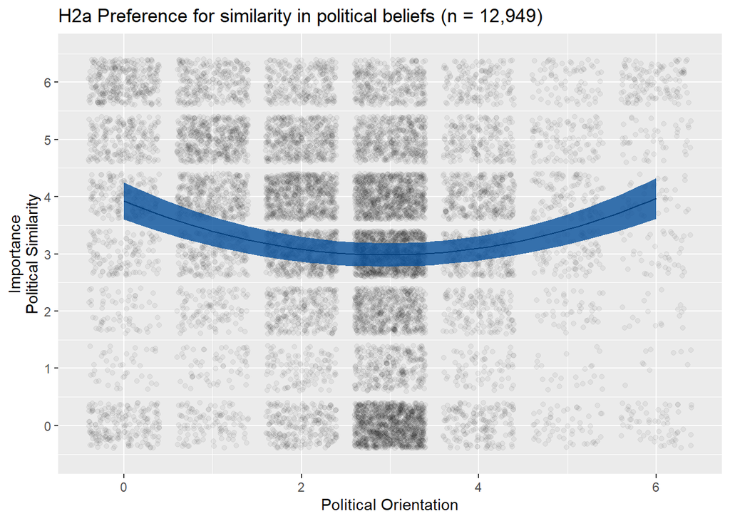

```r
effects2 = as.data.frame(effects2$political_orientation)

n = data_included_documented %>%
  filter(!is.na(pref_politicalsim)) %>%
  count()

plot2 = ggplot() +
  geom_jitter(data = data_included_documented, aes(x = political_orientation,
                                                   y = pref_politicalsim), alpha = 0.05) +
  geom_line(data = effects2, aes(x = political_orientation, y = fit)) +
  geom_ribbon(data = effects2, aes(x = political_orientation, ymin = lower, ymax = upper),
              fill = brewer.pal(9,"Blues")[8], alpha = 0.8) +
  scale_x_continuous(name = "Political Orientation") +
  scale_y_continuous(name = "Importance\nPolitical Similarity",
                     limits = c(-0.5,6.5),
                     breaks = c(0,1,2,3,4,5,6)) +
  ggtitle(paste0(
      "H2a Preference for similarity in political beliefs (n = ",
      prettyNum(n$n, big.mark = ",", preserve.width = "none"),
      ")"))
plot2
```

##### H2b Preference for similarity in ethnicity/race

H2b There is a positive linear link between right-wing political orientation and women’s preferences for partner’s similar ethnicity/race. Outcome: Preference ratings for partner’s similar ethnicity/race. Predictors: Political Orientation & Age. Random intercept and random slope for country.

###### Models

```r
model_pref_ethnicalsim_robustcheck <- lmer(pref_ethnicalsim ~ political_orientation + age + (1+political_orientation|country), data = data_included_documented)
```

###### Summary

```r
summary(model_pref_ethnicalsim_robustcheck)
```

```
## Linear mixed model fit by REML. t-tests use Satterthwaite's method [
## lmerModLmerTest]
## Formula:
## pref_ethnicalsim ~ political_orientation + age + (1 + political_orientation |
##     country)
##    Data: data_included_documented
##
## REML criterion at convergence: 30430.5
##
## Scaled residuals:
##     Min      1Q  Median      3Q     Max
## -3.2779 -0.4648 -0.0409  0.6023  2.4234
##
## Random effects:
##  Groups   Name                  Variance Std.Dev. Corr
##  country  (Intercept)           0.080770 0.28420
##           political_orientation 0.006379 0.07987  -0.40
##  Residual                       1.955409 1.39836
## Number of obs: 8641, groups:  country, 127
##
## Fixed effects:
##                        Estimate Std. Error        df t value Pr(>|t|)
## (Intercept)           2.805e+00  8.451e-02 6.408e+01  33.187  < 2e-16 ***
## political_orientation 1.420e-01  2.040e-02 2.528e+01   6.961 2.53e-07 ***
## age                   5.262e-03  2.158e-03 8.636e+03   2.438   0.0148 *
## ---
## Signif. codes:  0 '***' 0.001 '**' 0.01 '*' 0.05 '.' 0.1 ' ' 1
##
## Correlation of Fixed Effects:
##             (Intr) pltcl_
## pltcl_rnttn -0.573
## age         -0.637  0.018
```

```r
confint(model_pref_ethnicalsim_robustcheck, level = 0.997)
```

```
## Computing profile confidence intervals ...
```

```
##                             0.15 %   99.85 %
## .sig01                 0.105539436 0.5667043
## .sig02                -0.879729666 0.8025576
## .sig03                 0.030113047 0.1646381
## .sigma                 1.367138420 1.4306733
## (Intercept)            2.553361719 3.0755480
## political_orientation  0.071592573 0.2033169
## age                   -0.001137014 0.0116801
```

###### Standardized Coefficients

```r
standardize_parameters(model_pref_ethnicalsim_robustcheck, method = "basic", ci = 0.997)
```

```
## Parameter             | Coefficient (std.) |     1e+02% CI
## ----------------------------------------------------------
## (Intercept)           |               0.00 | [ 0.00, 0.00]
## political_orientation |               0.13 | [ 0.07, 0.18]
## age                   |               0.03 | [-0.01, 0.06]
##
## # Standardization method: Basic
```

###### Plot

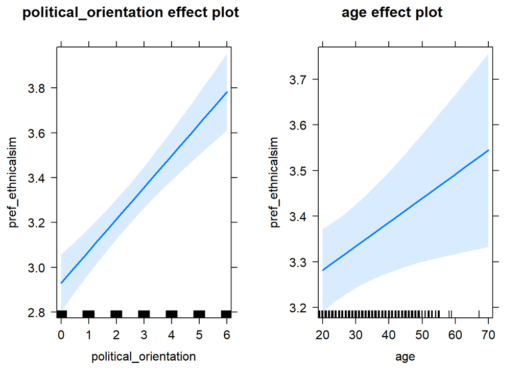

```r
lmer(pref_ethnicalsim ~ political_orientation + age + (1+political_orientation|country),
       data = data_included_documented) %>%
    allEffects() %>%
    plot()
```

##### H2c Preference for similarity in religion

H2c There is a positive linear link between right-wing political orientation and women’s preferences for partner’s similar religious beliefs.  
Outcome: Preference ratings for partner’s similar religious beliefs. Predictors: Political Orientation & Age. Random intercept and random slope for country.

###### Models

```r
model_pref_religioussim_robustcheck <- lmer(pref_religioussim ~ political_orientation + age + (1+political_orientation|country), data = data_included_documented)
```

###### Summary

```r
summary(model_pref_religioussim_robustcheck)
```

```
## Linear mixed model fit by REML. t-tests use Satterthwaite's method [
## lmerModLmerTest]
## Formula:
## pref_religioussim ~ political_orientation + age + (1 + political_orientation |
##     country)
##    Data: data_included_documented
##
## REML criterion at convergence: 56373.6
##
## Scaled residuals:
##      Min       1Q   Median       3Q      Max
## -2.44074 -1.00588  0.05918  0.84690  2.04254
##
## Random effects:
##  Groups   Name                  Variance Std.Dev. Corr
##  country  (Intercept)           0.403243 0.63501
##           political_orientation 0.006293 0.07933  -0.36
##  Residual                       4.519046 2.12580
## Number of obs: 12934, groups:  country, 144
##
## Fixed effects:
##                        Estimate Std. Error        df t value Pr(>|t|)
## (Intercept)           2.137e+00  1.200e-01 6.933e+01  17.803  < 2e-16 ***
## political_orientation 1.780e-01  2.255e-02 2.561e+01   7.894 2.52e-08 ***
## age                   3.327e-02  2.751e-03 1.291e+04  12.094  < 2e-16 ***
## ---
## Signif. codes:  0 '***' 0.001 '**' 0.01 '*' 0.05 '.' 0.1 ' ' 1
##
## Correlation of Fixed Effects:
##             (Intr) pltcl_
## pltcl_rnttn -0.518
## age         -0.570  0.033
```

```r
confint(model_pref_religioussim_robustcheck, level = 0.997)
```

```
## Computing profile confidence intervals ...
```

```
##                            0.15 %    99.85 %
## .sig01                 0.32713471 1.04263617
## .sig02                -0.91064683 0.96774274
## .sig03                 0.02046749 0.17154668
## .sigma                 2.08691097 2.16580486
## (Intercept)            1.75400882 2.57186768
## political_orientation  0.07661313 0.26975566
## age                    0.02508655 0.04142527
```

###### Standardized Coefficients

```r
standardize_parameters(model_pref_religioussim_robustcheck, method = "basic", ci = 0.997)
```

```
## Parameter             | Coefficient (std.) |    1e+02% CI
## ---------------------------------------------------------
## (Intercept)           |               0.00 | [0.00, 0.00]
## political_orientation |               0.11 | [0.07, 0.15]
## age                   |               0.10 | [0.08, 0.13]
##
## # Standardization method: Basic
```

###### Plot

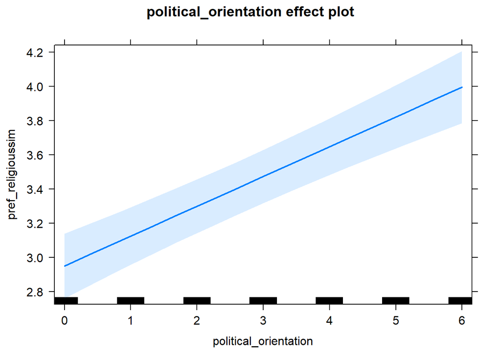

```r
lmer(pref_religioussim ~ political_orientation + (1+political_orientation|country),
       data = data_included_documented) %>%
    allEffects() %>%
    plot()
```

#### Ideal Partner Preferences

##### H3a Preference for the level of financial security- successfulness

H3a There is a positive linear link between right-wing political orientation and women’s preferences for the level of financial security and successfulness. Outcome: Level ratings for partner’s financial security-successfulness. Predictors: Political Orientation & Age. Random intercept and random slope for country.

###### Models

```r
#model_pref_level_financially_secure_successful_ambitious_robustcheck <- lmer(pref_level_financially_secure_successful_ambitious ~ political_orientation + age + (1+political_orientation|country), data = data_included_documented)

#drop random slope as model did not converge
model_pref_level_financially_secure_successful_ambitious_robustcheck <- lmer(pref_level_financially_secure_successful_ambitious ~ political_orientation + age + (1|country), data = data_included_documented)
```

###### Summary

```r
summary(model_pref_level_financially_secure_successful_ambitious_robustcheck)
```

```
## Linear mixed model fit by REML. t-tests use Satterthwaite's method [
## lmerModLmerTest]
## Formula:
## pref_level_financially_secure_successful_ambitious ~ political_orientation +
##     age + (1 | country)
##    Data: data_included_documented
##
## REML criterion at convergence: 31669.9
##
## Scaled residuals:
##     Min      1Q  Median      3Q     Max
## -4.8190 -0.6966  0.0070  0.6965  2.5683
##
## Random effects:
##  Groups   Name        Variance Std.Dev.
##  country  (Intercept) 0.08168  0.2858
##  Residual             0.72073  0.8490
## Number of obs: 12548, groups:  country, 143
##
## Fixed effects:
##                        Estimate Std. Error        df t value Pr(>|t|)
## (Intercept)           4.075e+00  4.752e-02 2.588e+02  85.763   <2e-16 ***
## political_orientation 8.987e-02  5.716e-03 1.253e+04  15.723   <2e-16 ***
## age                   9.457e-03  1.114e-03 1.252e+04   8.487   <2e-16 ***
## ---
## Signif. codes:  0 '***' 0.001 '**' 0.01 '*' 0.05 '.' 0.1 ' ' 1
##
## Correlation of Fixed Effects:
##             (Intr) pltcl_
## pltcl_rnttn -0.344
## age         -0.586  0.056
```

```r
confint(model_pref_level_financially_secure_successful_ambitious_robustcheck, level = 0.997)
```

```
## Computing profile confidence intervals ...
```

```
##                            0.15 %    99.85 %
## .sig01                0.201365067 0.40112228
## .sigma                0.833170405 0.86512580
## (Intercept)           3.934044492 4.22136999
## political_orientation 0.072909964 0.10684535
## age                   0.006149506 0.01276386
```

###### Standardized Coefficients

```r
standardize_parameters(model_pref_level_financially_secure_successful_ambitious_robustcheck, method = "basic", ci = 0.997)
```

```
## Parameter             | Coefficient (std.) |    1e+02% CI
## ---------------------------------------------------------
## (Intercept)           |               0.00 | [0.00, 0.00]
## political_orientation |               0.14 | [0.11, 0.16]
## age                   |               0.07 | [0.05, 0.10]
##
## # Standardization method: Basic
```

###### Plot

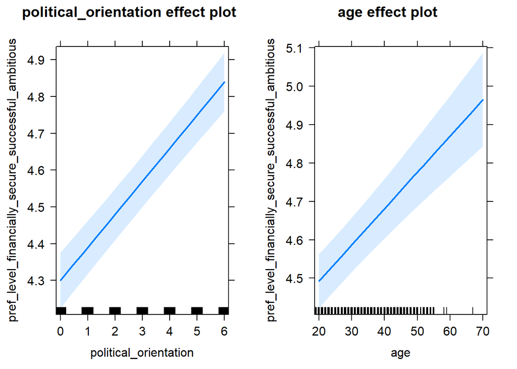

```r
lmer(pref_level_financially_secure_successful_ambitious ~ political_orientation + age + (1 | country),
       data = data_included_documented) %>%
    allEffects() %>%
    plot()
```

##### H3b Preference for the level of kindness-supportiveness

H3b There is no link between right-wing political orientation and women’s preferences for the level of kindness and supportiveness.  
Outcome: Level ratings for partner’s kindness-supportiveness. Predictors: Political Orientation & Age. Random intercept and random slope for country.

###### Models

```r
#model_pref_level_kind_supportive_robustcheck <- lmer(pref_level_kind_supportive ~ political_orientation + age + (1+political_orientation|country), data = data_included_documented)

#drop random slope as model did not converge
model_pref_level_kind_supportive_robustcheck <- lmer(pref_level_kind_supportive ~ political_orientation + age + (1|country), data = data_included_documented)
```

###### Summary

```r
summary(model_pref_level_kind_supportive_robustcheck)
```

```
## Linear mixed model fit by REML. t-tests use Satterthwaite's method [
## lmerModLmerTest]
## Formula: pref_level_kind_supportive ~ political_orientation + age + (1 |
##     country)
##    Data: data_included_documented
##
## REML criterion at convergence: 26527.9
##
## Scaled residuals:
##     Min      1Q  Median      3Q     Max
## -4.9118 -0.6678  0.0807  0.8272  1.7871
##
## Random effects:
##  Groups   Name        Variance Std.Dev.
##  country  (Intercept) 0.02039  0.1428
##  Residual             0.46639  0.6829
## Number of obs: 12726, groups:  country, 143
##
## Fixed effects:
##                        Estimate Std. Error        df t value Pr(>|t|)
## (Intercept)           5.045e+00  3.276e-02 4.648e+02 153.977   <2e-16 ***
## political_orientation 1.146e-02  4.538e-03 1.272e+04   2.525   0.0116 *
## age                   4.904e-03  8.925e-04 1.272e+04   5.494    4e-08 ***
## ---
## Signif. codes:  0 '***' 0.001 '**' 0.01 '*' 0.05 '.' 0.1 ' ' 1
##
## Correlation of Fixed Effects:
##             (Intr) pltcl_
## pltcl_rnttn -0.398
## age         -0.678  0.057
```

```r
confint(model_pref_level_kind_supportive_robustcheck, level = 0.997)
```

```
## Computing profile confidence intervals ...
```

```
##                             0.15 %     99.85 %
## .sig01                 0.098148526 0.206433539
## .sigma                 0.670332964 0.695810385
## (Intercept)            4.947616948 5.143521140
## political_orientation -0.002005723 0.024931831
## age                    0.002253309 0.007552103
```

###### Standardized Coefficients

```r
standardize_parameters(model_pref_level_kind_supportive_robustcheck, method = "basic", ci = 0.997)
```

```
## Parameter             | Coefficient (std.) |     1e+02% CI
## ----------------------------------------------------------
## (Intercept)           |               0.00 | [ 0.00, 0.00]
## political_orientation |               0.02 | [ 0.00, 0.05]
## age                   |               0.05 | [ 0.02, 0.07]
##
## # Standardization method: Basic
```

```r
ci(standardize_parameters(model_pref_level_kind_supportive_robustcheck, method = "basic"), ci = 0.997)
```

```
##               Parameter   CI       CI_low    CI_high
## 1           (Intercept) 99.7  0.000000000 0.00000000
## 2 political_orientation 99.7 -0.003909488 0.04846729
## 3                   age 99.7  0.022160590 0.07423996
```

```r
#calculate by hand to get exact numbers
```

###### Plot

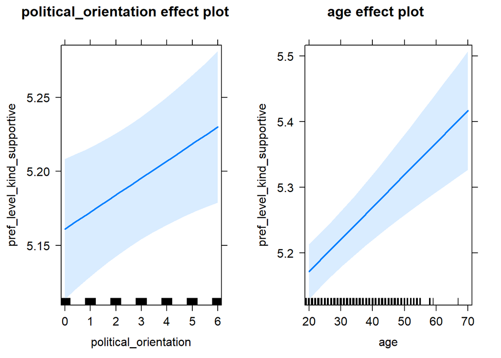

```r
lmer(pref_level_kind_supportive ~ political_orientation + age + (1|country),
       data = data_included_documented) %>%
    allEffects() %>%
    plot()
```

##### H3c Preference for the level of attractiveness

H3c There is no link between right-wing political orientation and women’s preferences for the level of attractiveness.  
Outcome: Level ratings for partner’s attractiveness. Predictors: Political Orientation & Age. Random intercept and random slope for country.

###### Models

```r
#model_pref_level_attractiveness_robustcheck <- lmer(pref_level_attractiveness ~ political_orientation + age + (1+political_orientation|country), data = data_included_documented)

#Model failed to converge, drop random slope:
model_pref_level_attractiveness_robustcheck <- lmer(pref_level_attractiveness ~ political_orientation + age + (1|country), data = data_included_documented)
```

###### Summary

```r
summary(model_pref_level_attractiveness_robustcheck)
```

```
## Linear mixed model fit by REML. t-tests use Satterthwaite's method [
## lmerModLmerTest]
## Formula: pref_level_attractiveness ~ political_orientation + age + (1 |
##     country)
##    Data: data_included_documented
##
## REML criterion at convergence: 32914.2
##
## Scaled residuals:
##     Min      1Q  Median      3Q     Max
## -4.6496 -0.6540 -0.0227  0.6521  2.5653
##
## Random effects:
##  Groups   Name        Variance Std.Dev.
##  country  (Intercept) 0.01521  0.1233
##  Residual             0.80546  0.8975
## Number of obs: 12523, groups:  country, 142
##
## Fixed effects:
##                         Estimate Std. Error         df t value Pr(>|t|)
## (Intercept)            3.961e+00  3.946e-02  7.059e+02 100.393  < 2e-16 ***
## political_orientation  4.067e-02  6.035e-03  1.246e+04   6.739 1.66e-11 ***
## age                   -1.539e-03  1.174e-03  1.251e+04  -1.312     0.19
## ---
## Signif. codes:  0 '***' 0.001 '**' 0.01 '*' 0.05 '.' 0.1 ' ' 1
##
## Correlation of Fixed Effects:
##             (Intr) pltcl_
## pltcl_rnttn -0.436
## age         -0.738  0.054
```

```r
confint(model_pref_level_attractiveness_robustcheck, level = 0.997)
```

```
## Computing profile confidence intervals ...
```

```
##                             0.15 %     99.85 %
## .sig01                 0.080240543 0.189695026
## .sigma                 0.880798612 0.914522257
## (Intercept)            3.844030859 4.078461130
## political_orientation  0.022731923 0.058579843
## age                   -0.005024393 0.001942756
```

###### Standardized Coefficients

```r
standardize_parameters(model_pref_level_attractiveness_robustcheck, method = "basic", ci = 0.997)
```

```
## Parameter             | Coefficient (std.) |     1e+02% CI
## ----------------------------------------------------------
## (Intercept)           |               0.00 | [ 0.00, 0.00]
## political_orientation |               0.06 | [ 0.03, 0.09]
## age                   |              -0.01 | [-0.04, 0.01]
##
## # Standardization method: Basic
```

###### Plot

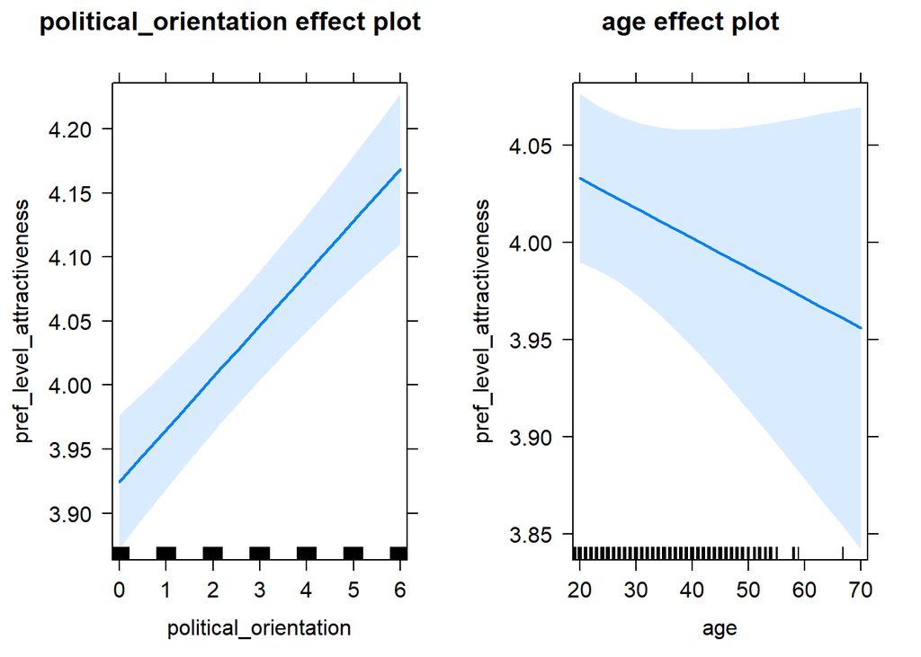

```r
lmer(pref_level_attractiveness ~ political_orientation + age + (1 | country),
       data = data_included_documented) %>%
    allEffects() %>%
    plot()
```

##### H3d Preference for the level of confidence-assertiveness

H3d There is a positive linear link between right-wing political orientation and women’s preferences for the level of confidence and assertiveness.  
Outcome: Level ratings for partner’s confidence-assertiveness. Predictors: Political Orientation & Age. Random intercept and random slope for country.

###### Models

```r
model_pref_level_confident_assertive_robustcheck <- lmer(pref_level_confident_assertive ~ political_orientation + age + (1+political_orientation|country), data = data_included_documented)
```

###### Summary

```r
summary(model_pref_level_confident_assertive_robustcheck)
```

```
## Linear mixed model fit by REML. t-tests use Satterthwaite's method [
## lmerModLmerTest]
## Formula: pref_level_confident_assertive ~ political_orientation + age +
##     (1 + political_orientation | country)
##    Data: data_included_documented
##
## REML criterion at convergence: 28704.2
##
## Scaled residuals:
##     Min      1Q  Median      3Q     Max
## -5.8511 -0.6602 -0.0056  0.6702  3.1600
##
## Random effects:
##  Groups   Name                  Variance  Std.Dev. Corr
##  country  (Intercept)           0.1561062 0.39510
##           political_orientation 0.0008453 0.02907  -0.54
##  Residual                       0.5512715 0.74248
## Number of obs: 12694, groups:  country, 144
##
## Fixed effects:
##                        Estimate Std. Error        df t value Pr(>|t|)
## (Intercept)           4.062e+00  5.347e-02 1.632e+02  75.978  < 2e-16 ***
## political_orientation 3.342e-02  7.959e-03 2.318e+01   4.199 0.000338 ***
## age                   1.481e-02  9.729e-04 1.265e+04  15.225  < 2e-16 ***
## ---
## Signif. codes:  0 '***' 0.001 '**' 0.01 '*' 0.05 '.' 0.1 ' ' 1
##
## Correlation of Fixed Effects:
##             (Intr) pltcl_
## pltcl_rnttn -0.510
## age         -0.456  0.036
```

```r
confint(model_pref_level_confident_assertive_robustcheck, level = 0.997)
```

```
## Computing profile confidence intervals ...
```

[output not shown]

[output cut: 202 more lines]

[output not shown]

```
##                             0.15 %    99.85 %
## .sig01                 0.293536683 0.53171662
## .sig02                -1.000000000 0.18235833
## .sig03                 0.006593520 0.06129969
## .sigma                 0.728761947 0.75657040
## (Intercept)            3.902864943 4.22349455
## political_orientation  0.007092237 0.05784956
## age                    0.011922192 0.01769817
```

###### Standardized Coefficients

```r
standardize_parameters(model_pref_level_confident_assertive_robustcheck, method = "basic", ci = 0.997)
```

```
## Parameter             | Coefficient (std.) |    1e+02% CI
## ---------------------------------------------------------
## (Intercept)           |               0.00 | [0.00, 0.00]
## political_orientation |               0.05 | [0.02, 0.09]
## age                   |               0.12 | [0.10, 0.14]
##
## # Standardization method: Basic
```

###### Plot

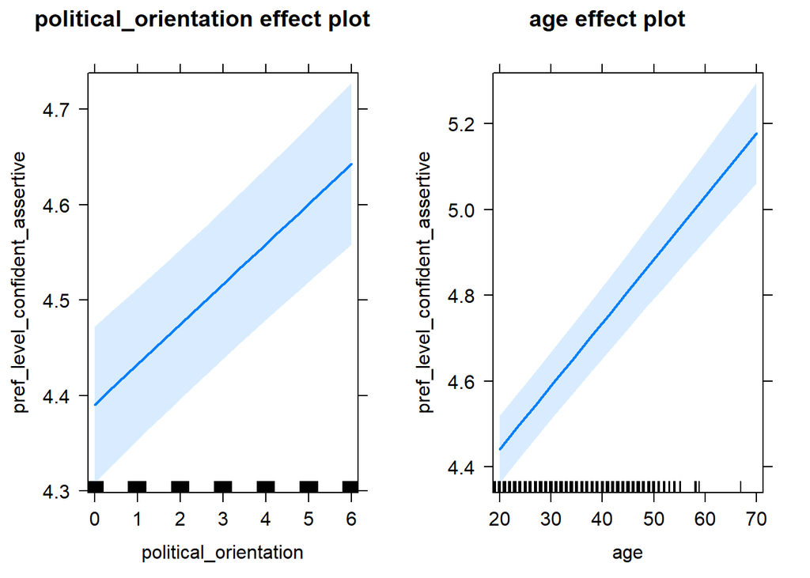

```r
lmer(pref_level_confident_assertive ~ political_orientation + age + (1|country),
       data = data_included_documented) %>%
    allEffects() %>%
    plot()
```

##### H3e Preference for the level of education-intelligence

H3e There is no link between right-wing political orientation and women’s preferences for the level of education and intelligence.  
Outcome: Level ratings for partner’s education-intelligence. Predictors: Political Orientation & Age. Random intercept and random slope for country.

###### Models

```r
#model_pref_level_intelligence_educated_robustcheck <- lmer(pref_level_intelligence_educated ~ political_orientation + age + (1+political_orientation|country), data = data_included_documented)

#Model failed to converge, drop random slope:
model_pref_level_intelligence_educated_robustcheck <- lmer(pref_level_intelligence_educated ~ political_orientation + age + (1|country), data = data_included_documented)
```

###### Summary

```r
summary(model_pref_level_intelligence_educated_robustcheck)
```

```
## Linear mixed model fit by REML. t-tests use Satterthwaite's method [
## lmerModLmerTest]
## Formula: pref_level_intelligence_educated ~ political_orientation + age +
##     (1 | country)
##    Data: data_included_documented
##
## REML criterion at convergence: 30068.8
##
## Scaled residuals:
##     Min      1Q  Median      3Q     Max
## -5.2385 -0.6794  0.0416  0.7032  2.1842
##
## Random effects:
##  Groups   Name        Variance Std.Dev.
##  country  (Intercept) 0.06232  0.2496
##  Residual             0.61459  0.7840
## Number of obs: 12720, groups:  country, 141
##
## Fixed effects:
##                        Estimate Std. Error        df t value Pr(>|t|)
## (Intercept)           4.588e+00  4.285e-02 3.455e+02 107.082  < 2e-16 ***
## political_orientation 1.665e-02  5.223e-03 1.271e+04   3.188  0.00144 **
## age                   9.353e-03  1.021e-03 1.270e+04   9.165  < 2e-16 ***
## ---
## Signif. codes:  0 '***' 0.001 '**' 0.01 '*' 0.05 '.' 0.1 ' ' 1
##
## Correlation of Fixed Effects:
##             (Intr) pltcl_
## pltcl_rnttn -0.348
## age         -0.595  0.053
```

```r
confint(model_pref_level_intelligence_educated_robustcheck, level = 0.997)
```

```
## Computing profile confidence intervals ...
```

```
##                            0.15 %    99.85 %
## .sig01                0.183941748 0.33947342
## .sigma                0.769481267 0.79875233
## (Intercept)           4.460771548 4.71680992
## political_orientation 0.001151178 0.03216490
## age                   0.006322820 0.01238105
```

###### Standardized Coefficients

```r
standardize_parameters(model_pref_level_intelligence_educated_robustcheck, method = "basic", ci = 0.997)
```

```
## Parameter             | Coefficient (std.) |    1e+02% CI
## ---------------------------------------------------------
## (Intercept)           |               0.00 | [0.00, 0.00]
## political_orientation |               0.03 | [0.00, 0.05]
## age                   |               0.08 | [0.05, 0.10]
##
## # Standardization method: Basic
```

```r
ci(standardize_parameters(model_pref_level_intelligence_educated_robustcheck, method = "basic"), ci = 0.997)
```

```
##               Parameter   CI      CI_low    CI_high
## 1           (Intercept) 99.7 0.000000000 0.00000000
## 2 political_orientation 99.7 0.001897715 0.05327907
## 3                   age 99.7 0.053268834 0.10430370
```

```r
#calculate by hand to get exact numbers
```

###### Plot

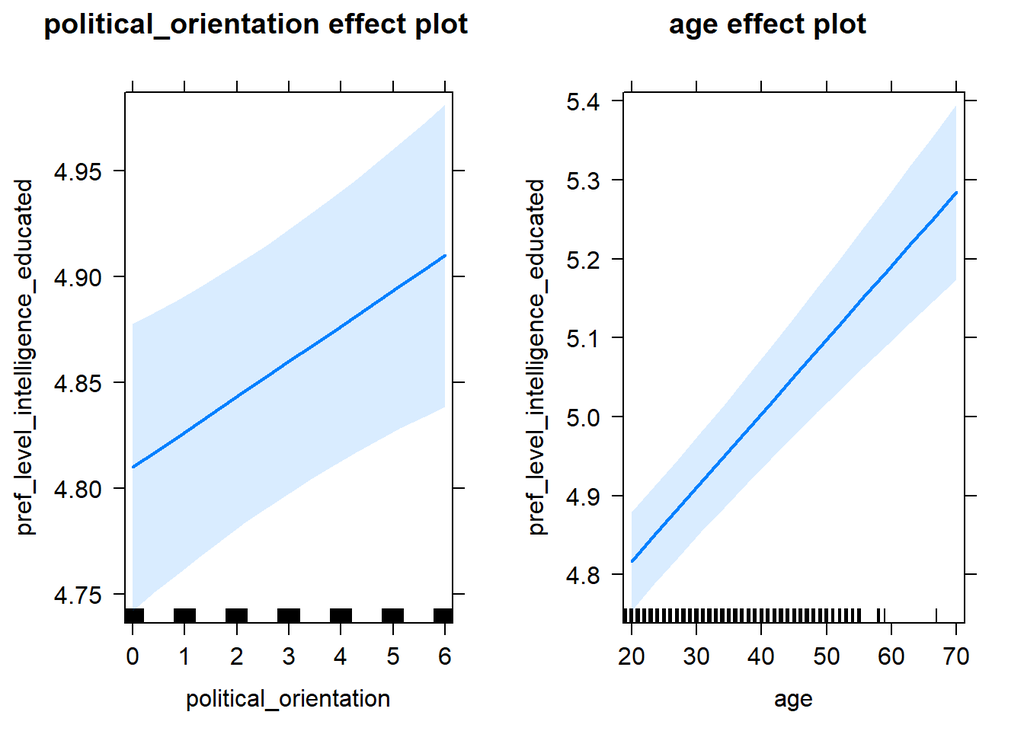

```r
lmer(pref_level_intelligence_educated ~ political_orientation + age + (1|country),
       data = data_included_documented) %>%
    allEffects() %>%
    plot()
```

#### Ideal age and height

##### H4a(1) Importance Ratings for partner’s age

H4a(1) There is a positive linear link between right-wing political orientation and women’s importance ratings for partner’s age. Outcome: Importance ratings for partner’s age. Predictors: Political Orientation & Age. Random intercept and random slope for country.

###### Models

```r
model_imp_age_robustcheck <- lmer(imp_age ~ political_orientation + age + (1+political_orientation|country), data = data_included_documented)
```

###### Summary

```r
summary(model_imp_age_robustcheck)
```

```
## Linear mixed model fit by REML. t-tests use Satterthwaite's method [
## lmerModLmerTest]
## Formula: imp_age ~ political_orientation + age + (1 + political_orientation |
##     country)
##    Data: data_included_documented
##
## REML criterion at convergence: 46120.5
##
## Scaled residuals:
##     Min      1Q  Median      3Q     Max
## -3.0860 -0.5065  0.1705  0.6534  2.1961
##
## Random effects:
##  Groups   Name                  Variance Std.Dev. Corr
##  country  (Intercept)           0.085463 0.29234
##           political_orientation 0.009756 0.09877  -0.77
##  Residual                       1.956241 1.39866
## Number of obs: 13109, groups:  country, 143
##
## Fixed effects:
##                         Estimate Std. Error         df t value Pr(>|t|)
## (Intercept)            3.716e+00  7.452e-02  5.221e+01  49.859  < 2e-16 ***
## political_orientation  7.908e-02  2.032e-02  1.539e+01   3.892  0.00138 **
## age                   -8.266e-03  1.796e-03  1.307e+04  -4.603 4.21e-06 ***
## ---
## Signif. codes:  0 '***' 0.001 '**' 0.01 '*' 0.05 '.' 0.1 ' ' 1
##
## Correlation of Fixed Effects:
##             (Intr) pltcl_
## pltcl_rnttn -0.683
## age         -0.597  0.024
```

```r
confint(model_imp_age_robustcheck, level= 0.997)
```

```
## Computing profile confidence intervals ...
```

```
##                             0.15 %      99.85 %
## .sig01                 0.110689802  0.560639793
## .sig02                -0.961434267  0.786347142
## .sig03                 0.006622679  0.203196813
## .sigma                 1.373282066  1.424910245
## (Intercept)            3.486463009  3.959721045
## political_orientation  0.011026257  0.147576380
## age                   -0.013606154 -0.002940114
```

###### Standardized Coefficients

```r
standardize_parameters(model_imp_age_robustcheck, method = "basic", ci = 0.997)
```

```
## Parameter             | Coefficient (std.) |      1e+02% CI
## -----------------------------------------------------------
## (Intercept)           |               0.00 | [ 0.00,  0.00]
## political_orientation |               0.08 | [ 0.02,  0.13]
## age                   |              -0.04 | [-0.07, -0.01]
##
## # Standardization method: Basic
```

###### Plot

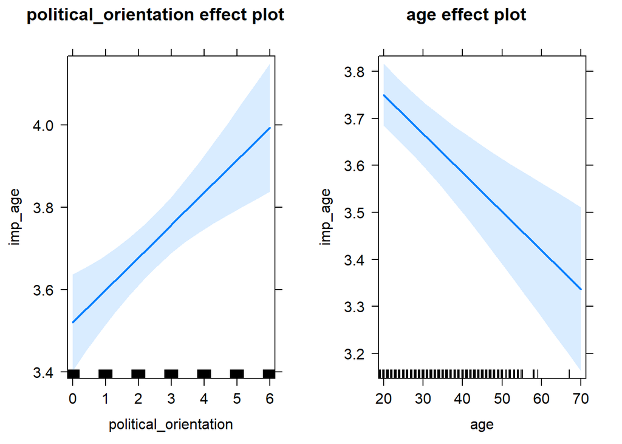

```r
lmer(imp_age ~ political_orientation + age + (1+political_orientation|country),
       data = data_included_documented) %>%
    allEffects() %>%
    plot()
```

##### H4a(2)Level Ratings for partner’s age

H4a(2) There is a positive linear link between right-wing political orientation and the relative age discrepancy between ideal partner’s age and women’s age. (discrepancy calculated as ideal partner’s age – women’s age) Outcome: Discrepancy between level ratings for ideal partner’s age and women’s age (ideal_age_rel) Predictors: Political Orientation & Age. Random intercept and random slope for country.

###### Models

```r
model_ideal_age_rel_robustcheck <- lmer(ideal_age_rel ~ political_orientation + age + (1+political_orientation|country), data = data_included_documented)
```

###### Summary

```r
summary(model_ideal_age_rel_robustcheck)
```

```
## Linear mixed model fit by REML. t-tests use Satterthwaite's method [
## lmerModLmerTest]
## Formula:
## ideal_age_rel ~ political_orientation + age + (1 + political_orientation |
##     country)
##    Data: data_included_documented
##
## REML criterion at convergence: 61595.1
##
## Scaled residuals:
##      Min       1Q   Median       3Q      Max
## -11.4254  -0.4968  -0.1225   0.4167  25.7466
##
## Random effects:
##  Groups   Name                  Variance Std.Dev. Corr
##  country  (Intercept)           0.8110   0.9006
##           political_orientation 0.4583   0.6770   -0.94
##  Residual                       9.5160   3.0848
## Number of obs: 12057, groups:  country, 140
##
## Fixed effects:
##                         Estimate Std. Error         df t value Pr(>|t|)
## (Intercept)            3.425e+00  1.762e-01  3.244e+01  19.442   <2e-16 ***
## political_orientation  1.469e-01  8.420e-02  3.640e+01   1.745   0.0894 .
## age                   -4.221e-02  4.158e-03  1.199e+04 -10.152   <2e-16 ***
## ---
## Signif. codes:  0 '***' 0.001 '**' 0.01 '*' 0.05 '.' 0.1 ' ' 1
##
## Correlation of Fixed Effects:
##             (Intr) pltcl_
## pltcl_rnttn -0.711
## age         -0.576  0.006
```

```r
confint(model_ideal_age_rel_robustcheck, level = 0.997)
```

```
## Computing profile confidence intervals ...
```

[output not shown]

###### Standardized Coefficients

```r
standardize_parameters(model_ideal_age_rel_robustcheck, method = "basic", ci = 0.997)
```

```
## Parameter             | Coefficient (std.) |      1e+02% CI
## -----------------------------------------------------------
## (Intercept)           |               0.00 | [ 0.00,  0.00]
## political_orientation |               0.06 | [-0.04,  0.17]
## age                   |              -0.09 | [-0.12, -0.07]
##
## # Standardization method: Basic
```

###### Plot

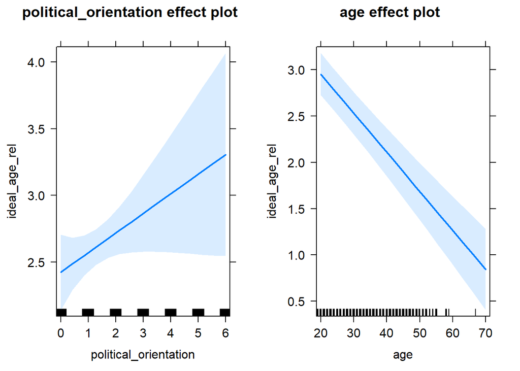

```r
lmer(ideal_age_rel ~ political_orientation + age + (1+political_orientation|country),
       data = data_included_documented) %>%
    allEffects() %>%
    plot()
```

##### H4b(1) Importance Ratings for partner’s height

H4b(1) There is a positive linear link between right-wing political orientation and women’s importance ratings for partner’s height. Outcome: Importance ratings for partner’s height. Predictors: Political Orientation & Age. Random intercept and random slope for country.

###### Models

```r
#model_imp_height_robustcheck <- lmer(imp_height ~ political_orientation + age + (1+political_orientation|country), data = data_included_documented)

#drop random slope as model did not converge
model_imp_height_robustcheck <- lmer(imp_height ~ political_orientation + age + (1|country), data = data_included_documented)
```

###### Summary

```r
summary(model_imp_height_robustcheck)
```

```
## Linear mixed model fit by REML. t-tests use Satterthwaite's method [
## lmerModLmerTest]
## Formula: imp_height ~ political_orientation + age + (1 | country)
##    Data: data_included_documented
##
## REML criterion at convergence: 46906.5
##
## Scaled residuals:
##     Min      1Q  Median      3Q     Max
## -3.3132 -0.5565  0.1014  0.7230  1.9957
##
## Random effects:
##  Groups   Name        Variance Std.Dev.
##  country  (Intercept) 0.07285  0.2699
##  Residual             2.13001  1.4595
## Number of obs: 13022, groups:  country, 143
##
## Fixed effects:
##                         Estimate Std. Error         df t value Pr(>|t|)
## (Intercept)            3.901e+00  6.717e-02  4.945e+02  58.082   <2e-16 ***
## political_orientation  1.212e-01  9.561e-03  1.301e+04  12.678   <2e-16 ***
## age                   -5.466e-03  1.877e-03  1.302e+04  -2.912   0.0036 **
## ---
## Signif. codes:  0 '***' 0.001 '**' 0.01 '*' 0.05 '.' 0.1 ' ' 1
##
## Correlation of Fixed Effects:
##             (Intr) pltcl_
## pltcl_rnttn -0.408
## age         -0.694  0.055
```

```r
confint(model_imp_height_robustcheck, level = 0.997)
```

```
## Computing profile confidence intervals ...
```

```
##                            0.15 %      99.85 %
## .sig01                 0.18010390 0.3971193814
## .sigma                 1.43284522 1.4866586923
## (Intercept)            3.70142696 4.1037526151
## political_orientation  0.09284674 0.1496373733
## age                   -0.01104549 0.0001037304
```

###### Standardized Coefficients

```r
standardize_parameters(model_imp_height_robustcheck, method = "basic", ci = 0.997)
```

```
## Parameter             | Coefficient (std.) |     1e+02% CI
## ----------------------------------------------------------
## (Intercept)           |               0.00 | [ 0.00, 0.00]
## political_orientation |               0.11 | [ 0.08, 0.14]
## age                   |              -0.03 | [-0.05, 0.00]
##
## # Standardization method: Basic
```

###### Plot

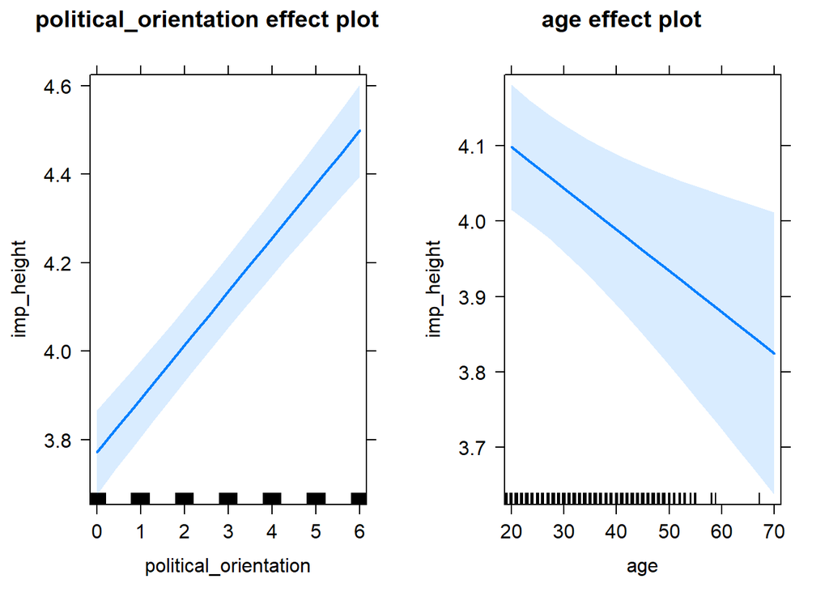

```r
lmer(imp_height ~ political_orientation + age + (1 | country),
       data = data_included_documented) %>%
    allEffects() %>%
    plot()
```

##### H4b(2)Level Ratings for partner’s height

H4b(2) There is a positive linear link between right-wing political orientation and ideal partner’s height. Outcome: Level ratings for ideal partner’s height. Predictors: Political Orientation & Age. Random intercept and random slope for country.

###### Models

```r
#model_ideal_height_robustcheck <- lmer(ideal_height ~ political_orientation + age + (1+political_orientation|country), data = data_included_documented)

#drop random slope as model did not converge
model_ideal_height_robustcheck <- lmer(ideal_height ~ political_orientation + age + (1|country), data = data_included_documented)
```

###### Summary

```r
summary(model_ideal_height_robustcheck)
```

```
## Linear mixed model fit by REML. t-tests use Satterthwaite's method [
## lmerModLmerTest]
## Formula: ideal_height ~ political_orientation + age + (1 | country)
##    Data: data_included_documented
##
## REML criterion at convergence: 14662.2
##
## Scaled residuals:
##     Min      1Q  Median      3Q     Max
## -7.1238 -0.1371 -0.0767  0.0022  2.6077
##
## Random effects:
##  Groups   Name        Variance Std.Dev.
##  country  (Intercept) 0.002562 0.05062
##  Residual             0.187659 0.43320
## Number of obs: 12520, groups:  country, 142
##
## Fixed effects:
##                         Estimate Std. Error         df t value Pr(>|t|)
## (Intercept)            1.111e+00  1.857e-02  5.093e+02  59.831  < 2e-16 ***
## political_orientation  1.432e-03  2.898e-03  1.234e+04   0.494    0.621
## age                   -3.218e-03  5.716e-04  1.248e+04  -5.630 1.85e-08 ***
## ---
## Signif. codes:  0 '***' 0.001 '**' 0.01 '*' 0.05 '.' 0.1 ' ' 1
##
## Correlation of Fixed Effects:
##             (Intr) pltcl_
## pltcl_rnttn -0.445
## age         -0.759  0.050
```

```r
confint(model_ideal_height_robustcheck, level = 0.997)
```

```
## Computing profile confidence intervals ...
```

```
##                             0.15 %      99.85 %
## .sig01                 0.026532017  0.087925535
## .sigma                 0.425147645  0.441440822
## (Intercept)            1.055818144  1.166610581
## political_orientation -0.007165490  0.010039884
## age                   -0.004913173 -0.001519517
```

###### Standardized Coefficients

```r
standardize_parameters(model_ideal_height_robustcheck, method = "basic", ci = 0.997)
```

```
## Parameter             | Coefficient (std.) |      1e+02% CI
## -----------------------------------------------------------
## (Intercept)           |               0.00 | [ 0.00,  0.00]
## political_orientation |           4.46e-03 | [-0.02,  0.03]
## age                   |              -0.05 | [-0.08, -0.02]
##
## # Standardization method: Basic
```

###### Plot

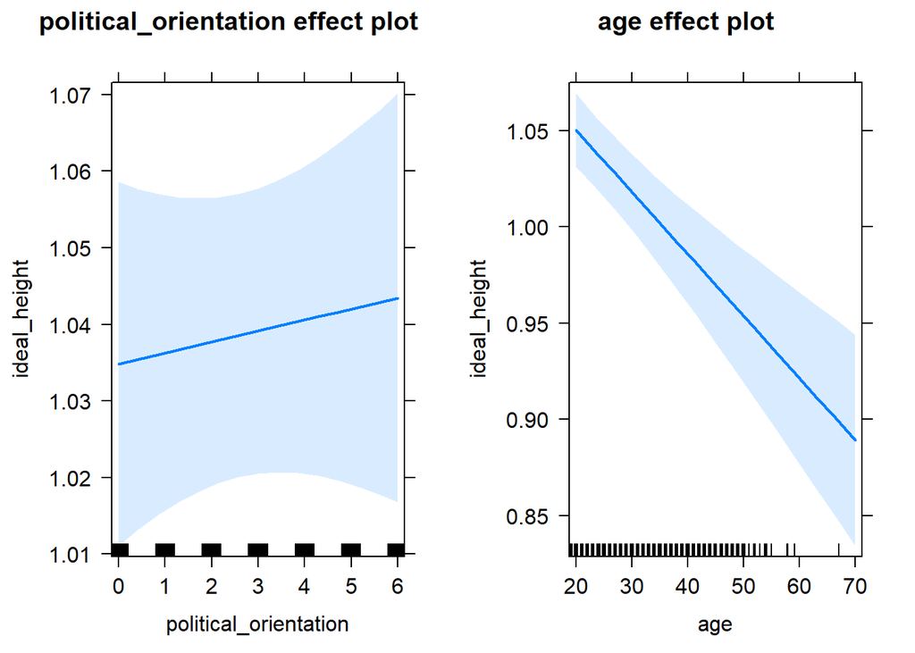

```r
lmer(ideal_height ~ political_orientation + age + (1 | country),
       data = data_included_documented) %>%
    allEffects() %>%
    plot()
```